# Coursera Data Scientist Capstone : Milestone Report

Joe Pogson

4/27/2020

## Introduction

This project will focus on developing a predictive model for text utlising natural language processing and a large body of text based data.

This report acts as a description for the major features to date for developing a predictive model based on exploratory data analysis.

## Getting the data

First we should set up the environmenr

```r
## Load Packages
library(downloader)
library(plyr)
library(dplyr)
library(knitr)
library(tm)
```

```r
library(stringi)
library(ggplot2)
library(RWeka)
```

Next we need to check if the data has been laoded to the local drive and if not download and unzip it.

```r
## Download Data if not already performed.
if(!file.exists("./Data")){
        dir.create("./Data")
}
Url <- "https://d396qusza40orc.cloudfront.net/dsscapstone/dataset/Coursera-SwiftKey.zip"
if(!file.exists("./Data/Coursera-SwiftKey.zip")){
        download.file(Url,destfile="./Data/Coursera-SwiftKey.zip",mode = "wb")
}
## Unzip Data (if not already)
        if(!file.exists("./coursera-swiftkey/coursera-swiftkey.zip")){
        unzip(zipfile="./Data/Coursera-SwiftKey.zip",exdir="./Data")
        }
```

Now we have the data downloaded and extracted we can start looking at it. We can see that data consists of several large text files in serveral languages(We will focus on the en_US files as english is my native language). There are different sources of data from News, Blogs and Twitter.

```r
path<-file.path("./Data/final","en_US")
files<-list.files(path,recursive=TRUE)
# File connection for twitter data
con <- file("./Data/final/en_US/en_US.twitter.txt","r")
lineTwitter<-readLines(con,skipNul = TRUE)
close(con)
# File connection for blog data
con <- file("./Data/final/en_US/en_US.blogs.txt","r")
lineBlogs<-readLines(con, skipNul = TRUE)
close(con)
# File connection for news data
con <- file("./Data/final/en_US/en_US.news.txt","r")
lineNews<-readLines(con, skipNul = TRUE)
close(con)
```

Now lets start looking at the size of the 3 data sets.

```r
lineBlogs.size <- file.info("./Data/final/en_US/en_US.blogs.txt")$size / 1024 ^ 2
lineNews.size <- file.info("./Data/final/en_US/en_US.news.txt")$size / 1024 ^ 2
lineTwitter.size <- file.info("./Data/final/en_US/en_US.twitter.txt")$size / 1024 ^ 2
# Get words in files
lineBlogs.words <- stri_count_words(lineBlogs)
lineNews.words <- stri_count_words(lineNews)
lineTwitter.words <- stri_count_words(lineTwitter)
# Summary of the data sets
data.frame(source = c("blogs","news","twitter"),
           file.size.MB = c(lineBlogs.size, lineNews.size, lineTwitter.size),
           num.lines = c(length(lineBlogs), length(lineNews), length(lineTwitter)),
           num.words = c(sum(lineBlogs.words), sum(lineNews.words), sum(lineTwitter.words)),
           mean.num.words = c(mean(lineBlogs.words), mean(lineNews.words), mean(lineTwitter.words)))
```

```
##    source file.size.MB num.lines num.words mean.num.words
## 1   blogs     200.4242    899288  38154238       42.42716
## 2    news     196.2775     77259   2693898       34.86840
## 3 twitter     159.3641   2360148  30218166       12.80350
```

## Data Cleaning

Ok we now know the size of the data we have but before we can progress into the exploratory stage we need to clean the data.

```r
# Get a sample of the data
set.seed(5000)
data.sample<-c(sample(lineBlogs,length(lineBlogs)*0.02),
               sample(lineNews,length(lineNews)*0.02),
               sample(lineTwitter,length(lineTwitter)*0.02))
# Create corpus and clean data
corpus<-VCorpus(VectorSource(data.sample))
toSpace<-content_transformer(function(x,pattern)gsub(pattern," ", x))
corpus<-tm_map(corpus,toSpace,"(f|ht)tp(s?)://(.*)[.][a-z]+")
corpus<-tm_map(corpus,toSpace,"@[^\\s]+")
corpus<-tm_map(corpus,tolower)
corpus<-tm_map(corpus,removeWords,stopwords("en"))
corpus<-tm_map(corpus,removePunctuation)
corpus<-tm_map(corpus,removeNumbers)
corpus<-tm_map(corpus,stripWhitespace)
corpus<-tm_map(corpus,PlainTextDocument)
```

## Exploratory Analysis

The data are now arranged and cleaned in a better format. Now it is time to start some basic analyses.

In order to get a better idea of how to predict the text it would be good to get an idea of the most popular ngrams.

```r
options(mc.cores=1)
getFreq <- function(tdm) {
  freq <- sort(rowSums(as.matrix(tdm)),decreasing=TRUE)
  return(data.frame(word=names(freq),freq=freq))
}
bigram <- function(x) NGramTokenizer(x, Weka_control(min = 2, max = 2))
trigram <- function(x) NGramTokenizer(x, Weka_control(min = 3, max = 3))
makePlot <- function(data, label) {
  ggplot(data[1:30,], aes(reorder(word,-freq),freq))+
         labs(x=label,y="Frequency")+
         theme(axis.text.x=element_text(angle=60,size=12,hjust=1)) +
         geom_bar(stat="identity",fill=I("black"))
}
# Frequencies of n-grams
unigrams <- getFreq(removeSparseTerms(TermDocumentMatrix(corpus), 0.9999))
bigrams <- getFreq(removeSparseTerms(TermDocumentMatrix(corpus, control = list(tokenize = bigram)), 0.9999))
trigrams <- getFreq(removeSparseTerms(TermDocumentMatrix(corpus, control = list(tokenize = trigram)), 0.9999))
```

Histogram of the most common uni-grams.

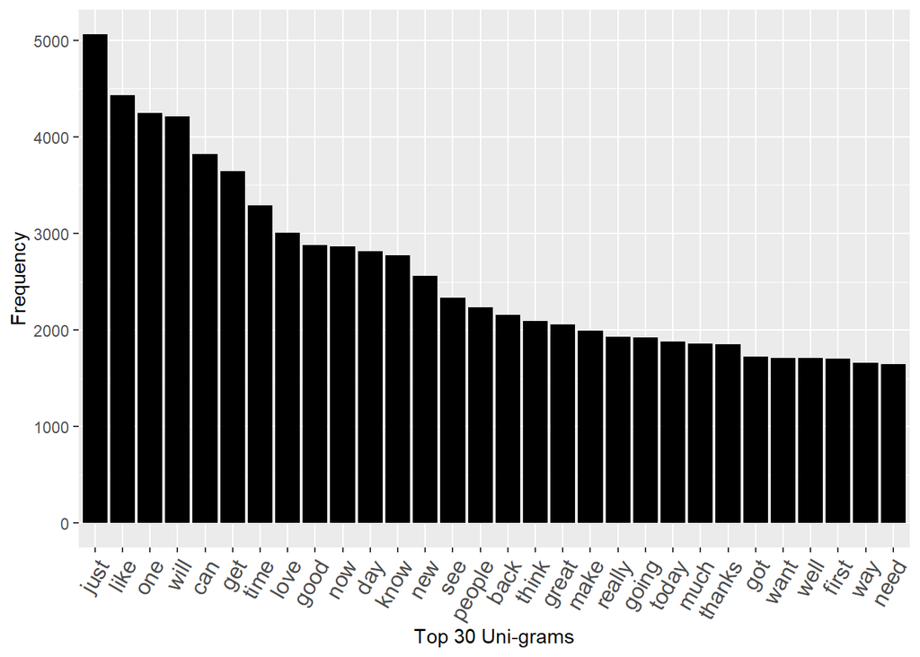

```r
makePlot(unigrams, "Top 30 Uni-grams")
```

Histogram of the most common bi-grams.

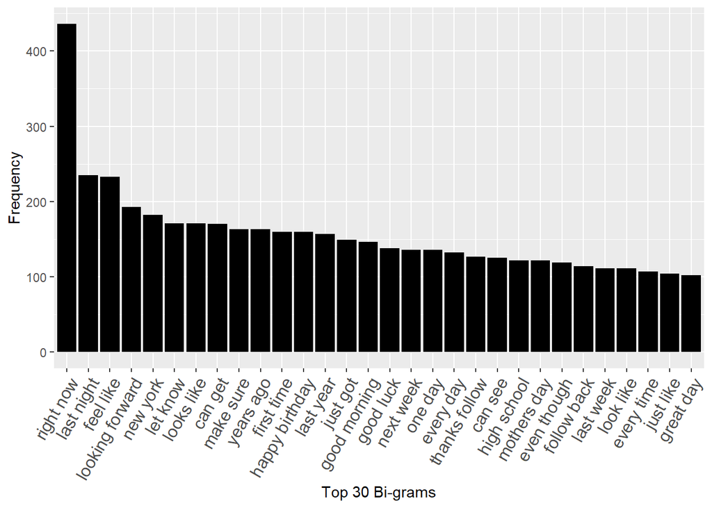

```r
makePlot(bigrams, "Top 30 Bi-grams")
```

Histogram of the most common tri-grams.

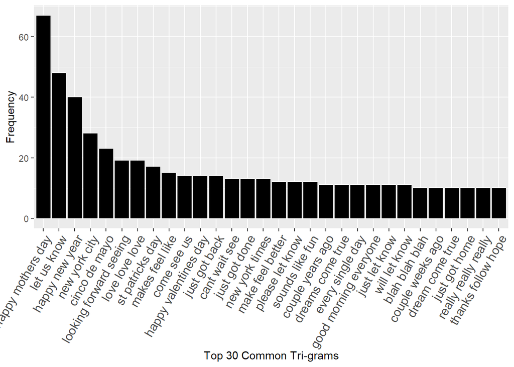

```r
makePlot(trigrams, "Top 30 Common Tri-grams")
```

## Conclusion

Here we can see the distribution of the most common ngrams that will be used for developing a predictive model.

A potential model could use several levels of model starting at a tri-gram prediction and then stepping down to bi-gram if no suitable tri-gram is identified

A text input box will be used in the Shiny app where a short phrase will be put through the algorithm and a suggested next word will be dispalyed.